# Homework 0

Yipin

September 15, 2018

# Assignment 0

## 1 Regularization.

Using the accompanying Hitters dataset (found here (Links to an external site.)Links to an external site.), we will explore regression models to predict a player’s Salary from other variables. You can use any programming languages or frameworks that you wish.

### 1.1 Use LASSO regression to predict Salary from the other numeric predictors (you should omit the categorical predictors).

#### 1.1.1. Create a visualization of the coefficient trajectories

```r
set.seed(123)
library(glmnet)
```

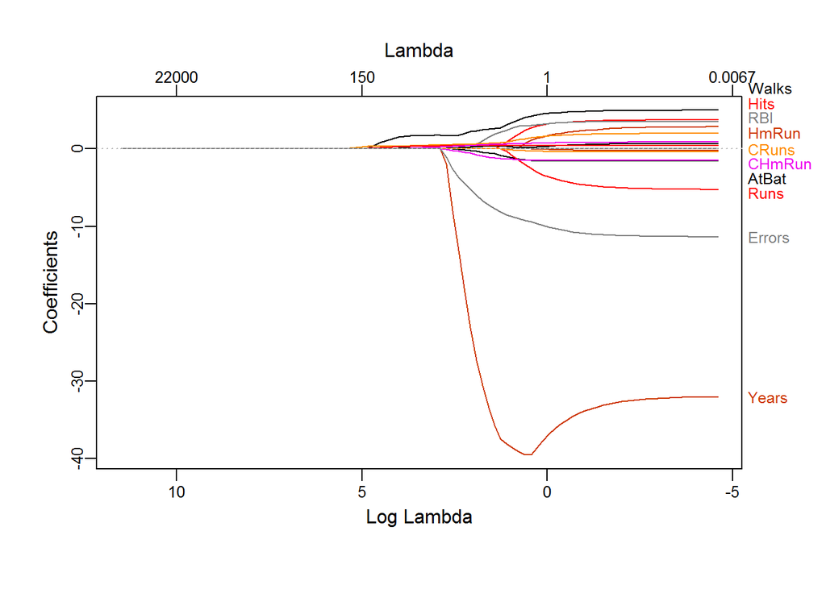

```r
library(plotmo)
df = read.csv("C:/Deep Learning/Homework1/Hitters.csv")
df = na.omit(df)
## remove categorical data
df = df[ , -which(names(df) %in% c("League", "Division", "X", "NewLeague"))]
grid = 10^seq(5, -2, length = 100)

x = model.matrix(Salary~., df)[,-1]
y = df$Salary

##generate training and testing dataset
train = sample(1:nrow(x),nrow(x)/2)
test = -train
y.test = y[test]

## make the trajectories
lasso.mod = glmnet(x[train,],y[train],alpha = 1, lambda = grid)
plot_glmnet(lasso.mod)
```

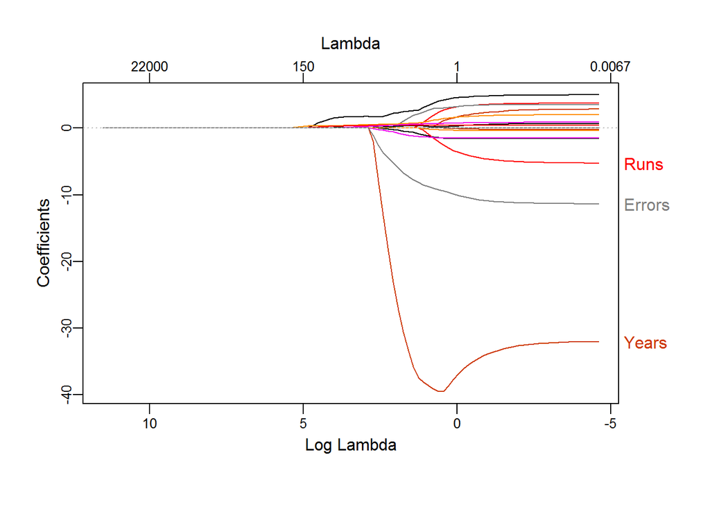

```r
plot_glmnet(lasso.mod, label=3)
```

#### 1.1.3. Use cross-validation to find the optimal value of the regularization penalty

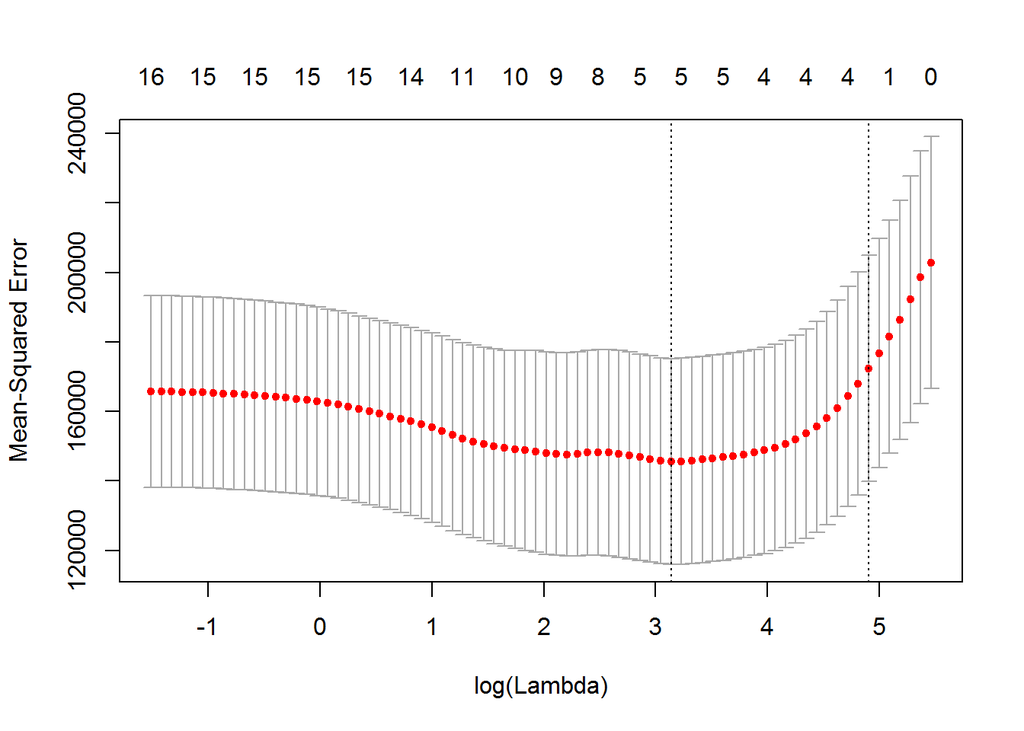

```r
cv.lasso = cv.glmnet(x[train,],y[train], alpha = 1)
plot(cv.lasso)
```

```r
bestlam = cv.lasso$lambda.min
cat("Best lambda is", bestlam)
```

```
## Best lambda is 23.03503
```

```r
lasso.pred = predict(lasso.mod, s = bestlam, newx = x[test,])
cat("\nMSE for the test dataset is", mean((lasso.pred - y[test])^2))
```

```
##
## MSE for the test dataset is 115520.6
```

#### 1.1.4. How many predictors are left in that model?

```r
lasso.out = glmnet(x,y, alpha = 1, lambda = grid)
lasso.coef = predict(lasso.out, type = "coefficients", s = bestlam)
print(lasso.coef)
```

```
## 17 x 1 sparse Matrix of class "dgCMatrix"
##                         1
## (Intercept) -2.399046e+01
## AtBat        .
## Hits         1.872269e+00
## HmRun        .
## Runs         .
## RBI          .
## Walks        2.205588e+00
## Years        .
## CAtBat       .
## CHits        .
## CHmRun       3.543539e-04
## CRuns        2.331654e-01
## CRBI         3.730225e-01
## CWalks       .
## PutOuts      2.058705e-01
## Assists      .
## Errors       .
```

6 predictors are left in that model.

### 1.2 Repeat with Ridge Regression.

#### 1.2.1 Visualize the coefficient trajectories

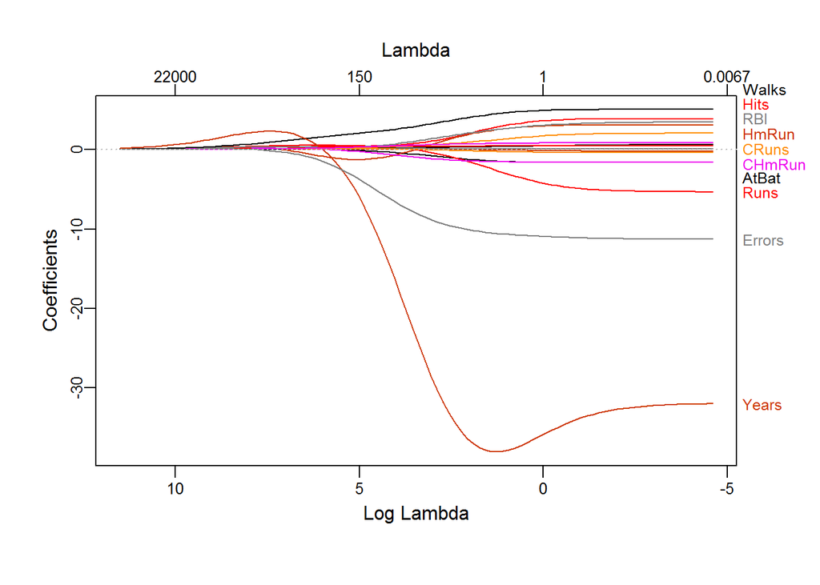

```r
ridge.mod = glmnet(x[train,],y[train],alpha = 0, lambda = grid)
plot_glmnet(ridge.mod)
```

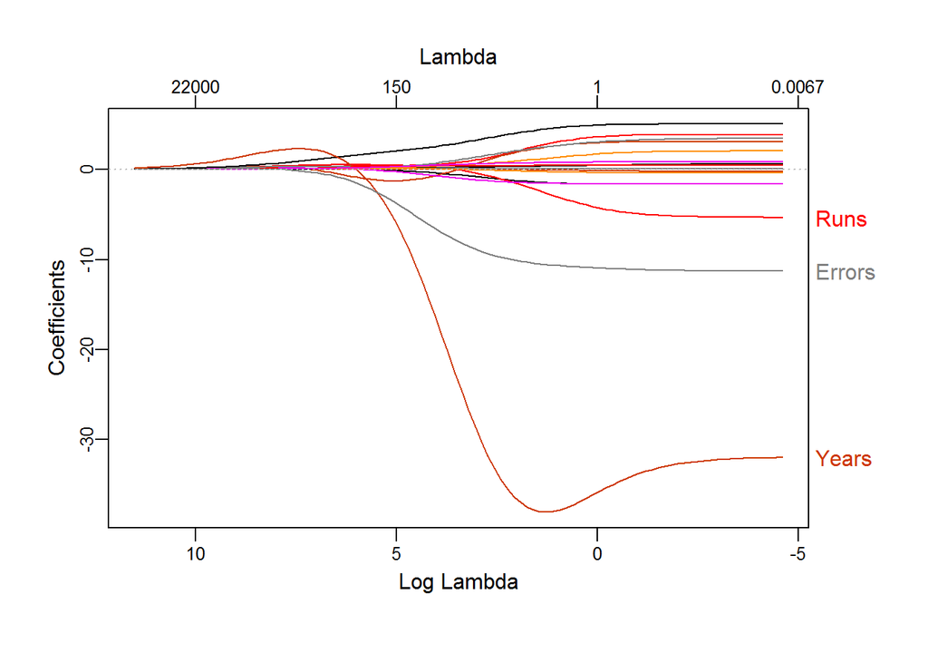

```r
plot_glmnet(ridge.mod, label=3)
```

#### 1.2.2 Use cross-validation to find the optimal value of the regularization penalty

```r
cv.lasso = cv.glmnet(x[train,],y[train], alpha = 0)
bestlam = cv.lasso$lambda.min
cat("Best lambda is", bestlam,"\n")
```

```
## Best lambda is 350.112
```

```r
ridge.out = glmnet(x,y, alpha = 0, lambda = grid)
ridge.coef = predict(ridge.out, type = "coefficients", s = bestlam)
print(ridge.coef)
```

```
## 17 x 1 sparse Matrix of class "dgCMatrix"
##                        1
## (Intercept) -10.56131640
## AtBat         0.07635173
## Hits          0.84721575
## HmRun         0.46421411
## Runs          1.07881681
## RBI           0.91040622
## Walks         1.63826327
## Years         1.51429627
## CAtBat        0.01123927
## CHits         0.05635496
## CHmRun        0.39079801
## CRuns         0.11415871
## CRBI          0.11811442
## CWalks        0.05982305
## PutOuts       0.16509612
## Assists       0.03053209
## Errors       -1.22456904
```

```r
ridge.pred = predict(ridge.mod, s = bestlam, newx = x[test,])
cat("\nMSE for the test dataset is", mean((ridge.pred - y[test])^2))
```

```
##
## MSE for the test dataset is 110602.1
```

The L2 regularization does not push the coefficients to 0. Instead, it will make them very small. It also decreases the variance with a slight increase in bias.

## 2 Short Answer.

### 2.1 Explain in your own words the bias-variance tradeoff

When training the machine learning models, we cannot minimize the bias and the variance at the same time. When we try to reduce the bias, the variance increases. When the variance decreases, the bias also increases.

### 2.2 What role does regularization play in this tradeoff?

The regularization is a useful way for us to find the midpoint of bias-variance tradeoff. It will put a penalty towards coefficients of predictors that are not significant. It can reduce the variance when the bias increases a little bit.

### 2.3 Make reference to your findings in number (1) to describe models of high/low bias and variance

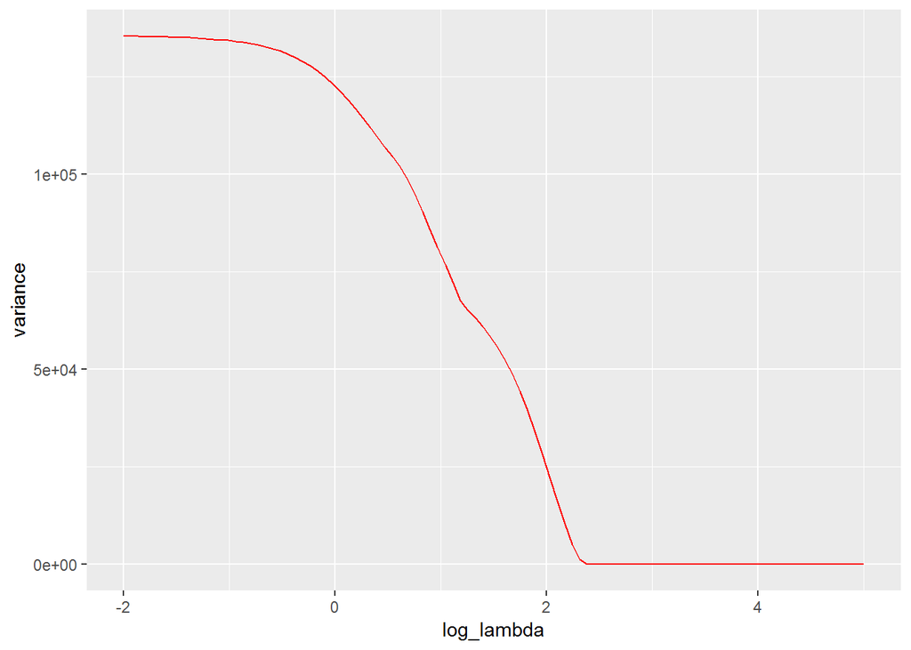

```r
library(ggplot2)
grid2 = 10^seq(5, -2, length = 100)
variance = numeric(100)
mse = numeric(100)
for(i in 1:100){
  lambda <- grid2[i]
  lasso.pred = predict(lasso.mod, s = lambda, newx = x[test,])
  variance[i] = var(lasso.pred)
  mse[i] = mean((lasso.pred - y[test])^2)
}

df2 <- data.frame(log(grid2, base = 10), mse, variance)
colnames(df2)[colnames(df2) == "log.grid2..base...10."] <-  "log_lambda"
ggplot(df2)+
  geom_line(aes(log_lambda,variance),color = "red")
```

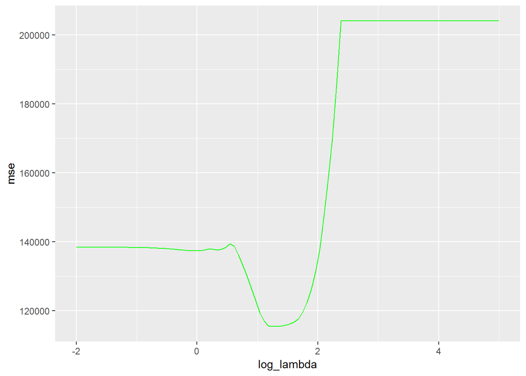

```r
ggplot(df2)+
  geom_line(aes(log_lambda,mse),color = "green")
```

Moreover, because a fixed bias is much easier for us to adjust, sometimes we can utilize the tradeoff to get an excellent result, with a minimal variance and a large but fixed bias.